Анализ частоты гибридов был очень непростым!

Сделать этот анализх только по данным Тювы нельзя, так как там очень мало разрезов в которых есть честные данные по Structure. Вот эти точки.

```
##  [1] "BN_+0.5_05"   "BS_+0.5_04"   "BS_+0.5_09"   "BS_+0.5_12"   "BS_+0.5_18"
##  [6] "BS_-1.5_05"   "BS_-1.5_09"   "BS_-1.5_18"   "BS_+1.5-1_03" "BS_+1.5-2_03"
## [11] "BS_+1_05"     "BS_+2_05"     "BS_+2_09"     "MidN_+0.5_05" "MidN_+0.5_10"
## [16] "MidN_+0.5_12" "MidN_+0.5_18" "MidN_-1.5_10" "MidN_-1.5_12" "MidN_-1.5_18"
## [21] "MidN_+2_10"   "MidS_+0.5_05" "MoN_+0.5_04"  "MoS_+0.5_05"  "MoS_+0.5_09"
## [26] "MoS_+0.5_12"  "MoS_+0.5_18"  "MoS_-1.5_09"  "MoS_-1.5_12"  "MoS_-1.5_18"
## [31] "MoS_+2_10"    "Ug_+0.5_05"   "Ug_-1.5_05"   "R_+0.5_05"    "R_+0.5_09"
## [36] "R2_+0.5_05"
```

Точнее даже их меньше, так как значения предикторов определялись для сайта

```
##  [1] "BN_+0.5"   "BS_+0.5"   "BS_-1.5"   "BS_+1.5"   "BS_+1_05"  "BS_+2"
##  [7] "MidN_+0.5" "MidN_-1.5" "MidN_+2"   "MidS_+0.5" "MoN_+0.5"  "MoS_+0.5"
## [13] "MoS_-1.5"  "MoS_+2"    "Ug_+0.5"   "Ug_-1.5"   "R_+0.5"    "R2_+0.5"
```

Установить какие-то значимые связи частоты гибридов с предикторами не удается.

Поэтому я взял все данные по Кольскому заливу (включая Тюву), убрав из них сайты, которые явно за пределами основного массива данных. Вот эти сайты.

```
## [1] "Ura Inlet"          "Mogil'naya"         "Kil'din, sunduki"
## [4] "Kil'dinskaya salma"
```

Дадее анализ идет на основе данных вот с этих выборок.

```
##   [1] "Ab_01"        "Ab_08"        "Ab_16"        "Ab_22"        "Be1_05"
##   [6] "Be1_09"       "Be1_16"       "Be1_21"       "ZM_08"        "ZM_16"
##  [11] "ZM_22"        "Mi_02"        "Mi_16"        "Mi_22"        "Re_04"
##  [16] "Re_10"        "Re_16"        "Re_22"        "Sev_03"       "Sev_17"
##  [21] "Sev_22"       "NM1_08"       "NM1_14"       "NM1_22"       "NM2_08"
##  [26] "NM2_14"       "FR"           "At"           "Sr"           "Dr2"
##  [31] "Dr1"          "Pr"           "Mal"          "Nav"          "Ch1"
##  [36] "Dr3_-1.5"     "Dr3_-2.5"     "Dr3_-3.5"     "Dr3_-5"       "Dr3_-6"
##  [41] "Tu1"          "Tu2_-6-7"     "Tu2_-8-9"     "Tu2_-10"      "Tu2_-11"
##  [46] "YuR"          "TriR_21"      "TriR_11"      "El1"          "El2_-2.5-3"
##  [51] "El2_-4"       "El2_-4.5"     "Ch2_-0.1-0.5" "Ch2_-1"       "Ch2_-2"
##  [56] "Ch2_-2.5"     "Be2"          "Pa_05"        "Pa_23"        "Kis_04"
##  [61] "Kis_23"       "Ol"           "Ku"           "Gr_b"         "Gr_a"
##  [66] "Lo"           "Vo"           "ZZ"           "Ret_f"        "BN_+0.5_05"
##  [71] "BS_+0.5_04"   "BS_+0.5_09"   "BS_+0.5_12"   "BS_+0.5_18"   "BS_-1.5_05"
##  [76] "BS_-1.5_09"   "BS_-1.5_18"   "BS_+1.5-1_03" "BS_+1.5-2_03" "BS_+1_05"
##  [81] "BS_+2_05"     "BS_+2_09"     "MidN_+0.5_05" "MidN_+0.5_10" "MidN_+0.5_12"
##  [86] "MidN_+0.5_18" "MidN_-1.5_10" "MidN_-1.5_12" "MidN_-1.5_18" "MidN_+2_10"
##  [91] "MidS_+0.5_05" "MoN_+0.5_04"  "MoS_+0.5_05"  "MoS_+0.5_09"  "MoS_+0.5_12"
##  [96] "MoS_+0.5_18"  "MoS_-1.5_09"  "MoS_-1.5_12"  "MoS_-1.5_18"  "MoS_+2_10"
## [101] "Ug_+0.5_05"   "Ug_-1.5_05"   "R_+0.5_05"    "R_+0.5_09"    "R2_+0.5_05"
```

В каждой выборке за гибридов я считал тех, у кого 0.1 < str < 0.9.

Далее в качестве основного предиктора, который говорит что-то про соленость (и возможно еще что-то) буду использовать расстояние от устья Туломы. На всякий случай показываю, что это расстояние - прокси для солености, даже в оценке через базу ORACLE, которая хороша для макрогеографии, но на таких масштабах дает нереалистичные значения.

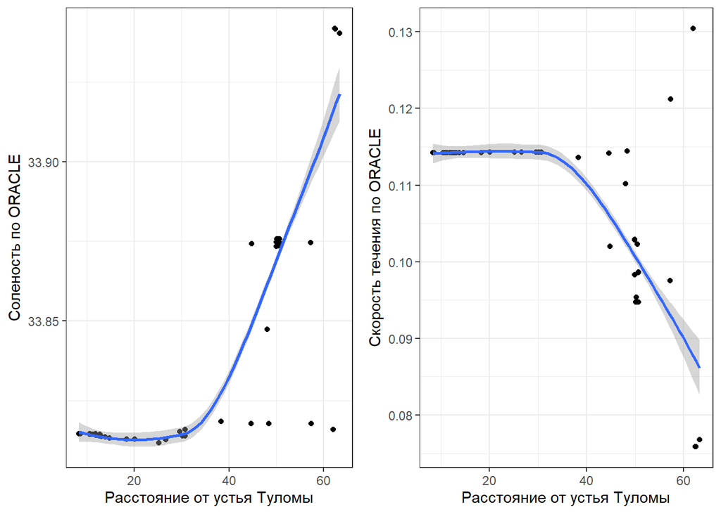

Важно отметить, что на расстоянии около 30 км начинается повышение солености и снижается скорость течения, то есть происходит какое-то изменение гидрологического режима, заметное даже для модели ORACLE.

### Модель

Просто вот так описать связь частоты гибридов с расстоянием от Туломы нельзя. С очевидностью надо учитывать еще и среднее значение STRUCTURE. Вот так меняется STRUCTURE по мере увеличения расстояния от Туломы.

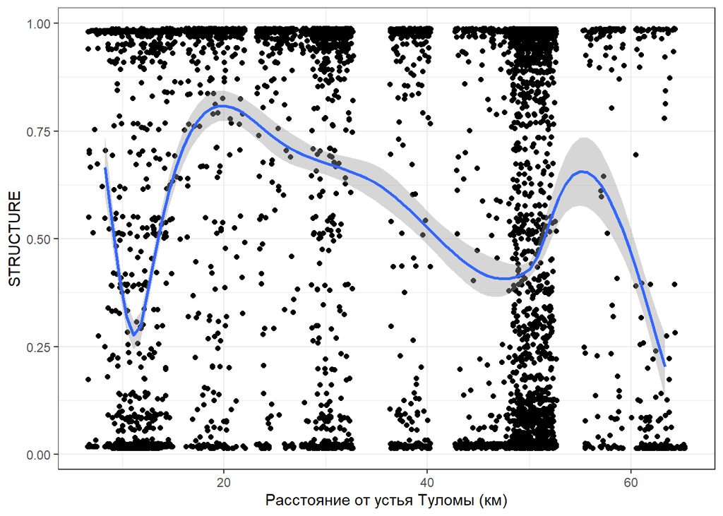

После долгого траха с моделью стало понятно, что неучитывать взаимодействие Distance_Tuloma:Mean_str нельзя. Поэтому в модели будет взаимодействие (забегая вперед - значимое). Стало быть, main effect каждого из предикторов - отражает лишь часть правды.

Вот summary построенной модели.

```
##
## Family: binomial
## Link function: logit
##
## Formula:
## cbind(N_hybr, N_pure) ~ s(Distance_Tuloma, k = -1) + s(Mean_str,
##     k = 5) + ti(Distance_Tuloma, Mean_str, k = c(8, 6))
##
## Parametric coefficients:
##             Estimate Std. Error z value Pr(>|z|)
## (Intercept)  -1.7094     0.0753   -22.7   <2e-16 ***
## ---
## Signif. codes:  0 '***' 0.001 '**' 0.01 '*' 0.05 '.' 0.1 ' ' 1
##
## Approximate significance of smooth terms:
##                                 edf Ref.df Chi.sq p-value
## s(Distance_Tuloma)            7.680  8.204  79.22  <2e-16 ***
## s(Mean_str)                   3.873  3.955  37.07  <2e-16 ***
## ti(Distance_Tuloma,Mean_str) 22.205 24.729 200.20  <2e-16 ***
## ---
## Signif. codes:  0 '***' 0.001 '**' 0.01 '*' 0.05 '.' 0.1 ' ' 1
##
## R-sq.(adj) =  0.512   Deviance explained = 55.6%
## -REML = 860.28  Scale est. = 1         n = 321
```

Главные эффекты и их взаимодействие значимы.

Вот главный эффект STRUCTURE, то есть то, как меняется частота гибридов в зависимость от среднего значения STRUCTURE. Здесь и далее горизонтальная лини отражает среднее для всего массива значение частоты гибридов. Точки - первичные данные. НО!!! Помним, что первичные данные в этих осях - это **ФЭЙК**! Для множественных моделей предсказанное значение (линия регрессии) это то, что отражает связь с данным предиктором при условии, что остальные предикторы неизменны (например, равны среднему). В первичных данных такого partial effect нет!!! Поэтому предсказанное значение может сильно не совпадать с первичными данными. Как понял?

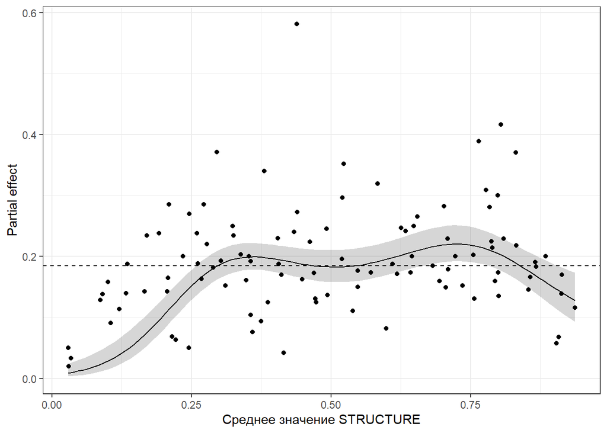

Вот главный эффект расстояния от Туломы.

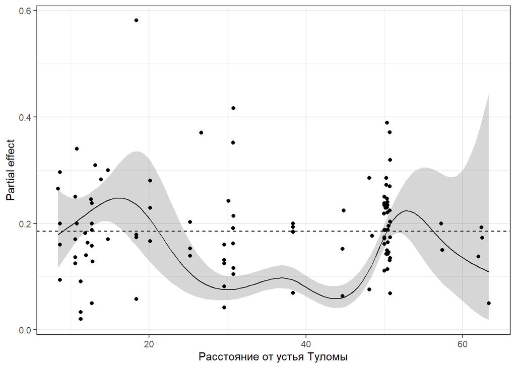

Здесь надо увидеть, что если мы возьмем точку, расположенную ближе к Туломе, то модель предсказывает частоту гибридов выше среднего. По мере удаления от кута частота становится ниже среднего. Что там за горб справа не понимаю, но он значимо не отличается от среднего.

Гораздо информативнее смотреть на взаимодействие.

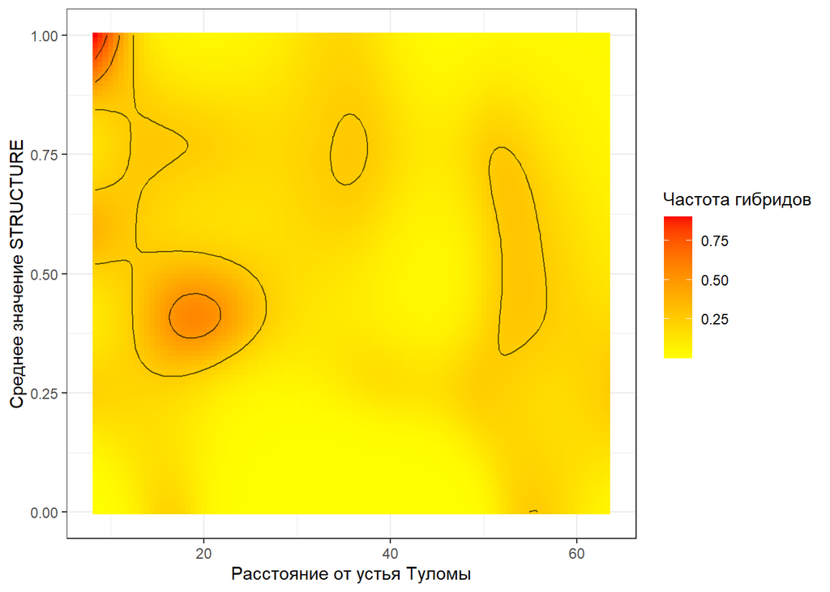

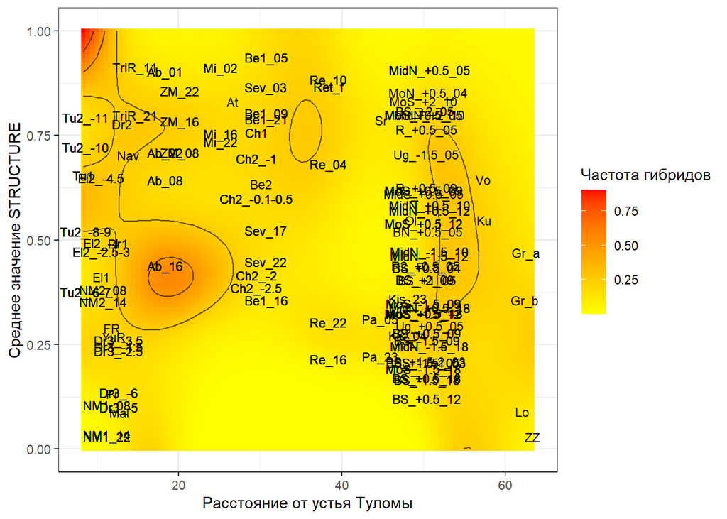